# Water Potability Prediction

Colin Hicks

8/25/2021

# Summary

Implementation of predictive models to determine if the sample tested from a body of water is fit for human consumption. This project includes exploratory analysis, data cleaning, preprocessing, and execution of KNN and Random Forest models for comparison.

###### [Data Source](https://www.kaggle.com/adityakadiwal/water-potability)

## View Data

```r
wq_df <- read.csv("/Users/colinhicks/Documents/data_science/data_sets/water_quality/water_potability.csv")
```

```
##         ph Hardness   Solids Chloramines  Sulfate Conductivity Organic_carbon
## 1       NA 204.8905 20791.32    7.300212 368.5164     564.3087      10.379783
## 2 3.716080 129.4229 18630.06    6.635246       NA     592.8854      15.180013
## 3 8.099124 224.2363 19909.54    9.275884       NA     418.6062      16.868637
## 4 8.316766 214.3734 22018.42    8.059332 356.8861     363.2665      18.436524
## 5 9.092223 181.1015 17978.99    6.546600 310.1357     398.4108      11.558279
## 6 5.584087 188.3133 28748.69    7.544869 326.6784     280.4679       8.399735
##   Trihalomethanes Turbidity Potability
## 1        86.99097  2.963135          0
## 2        56.32908  4.500656          0
## 3        66.42009  3.055934          0
## 4       100.34167  4.628771          0
## 5        31.99799  4.075075          0
## 6        54.91786  2.559708          0
```

```
##        ph            Hardness          Solids         Chloramines
##  Min.   : 0.000   Min.   : 47.43   Min.   :  320.9   Min.   : 0.352
##  1st Qu.: 6.093   1st Qu.:176.85   1st Qu.:15666.7   1st Qu.: 6.127
##  Median : 7.037   Median :196.97   Median :20927.8   Median : 7.130
##  Mean   : 7.081   Mean   :196.37   Mean   :22014.1   Mean   : 7.122
##  3rd Qu.: 8.062   3rd Qu.:216.67   3rd Qu.:27332.8   3rd Qu.: 8.115
##  Max.   :14.000   Max.   :323.12   Max.   :61227.2   Max.   :13.127
##  NA's   :491
##     Sulfate       Conductivity   Organic_carbon  Trihalomethanes
##  Min.   :129.0   Min.   :181.5   Min.   : 2.20   Min.   :  0.738
##  1st Qu.:307.7   1st Qu.:365.7   1st Qu.:12.07   1st Qu.: 55.845
##  Median :333.1   Median :421.9   Median :14.22   Median : 66.622
##  Mean   :333.8   Mean   :426.2   Mean   :14.28   Mean   : 66.396
##  3rd Qu.:360.0   3rd Qu.:481.8   3rd Qu.:16.56   3rd Qu.: 77.337
##  Max.   :481.0   Max.   :753.3   Max.   :28.30   Max.   :124.000
##  NA's   :781                                     NA's   :162
##    Turbidity       Potability
##  Min.   :1.450   Min.   :0.0000
##  1st Qu.:3.440   1st Qu.:0.0000
##  Median :3.955   Median :0.0000
##  Mean   :3.967   Mean   :0.3901
##  3rd Qu.:4.500   3rd Qu.:1.0000
##  Max.   :6.739   Max.   :1.0000
##
```

## Observe label counts

```
##   Potability count
## 1      FALSE  1200
## 2       TRUE   811
```

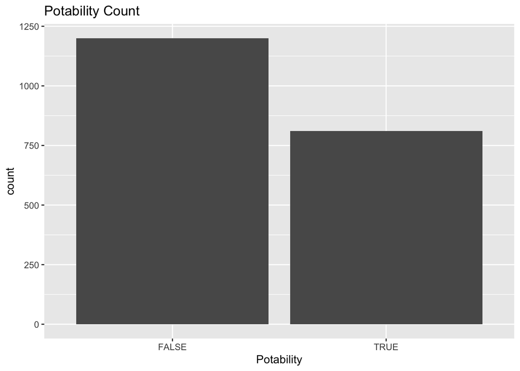

## Feature Boxplots

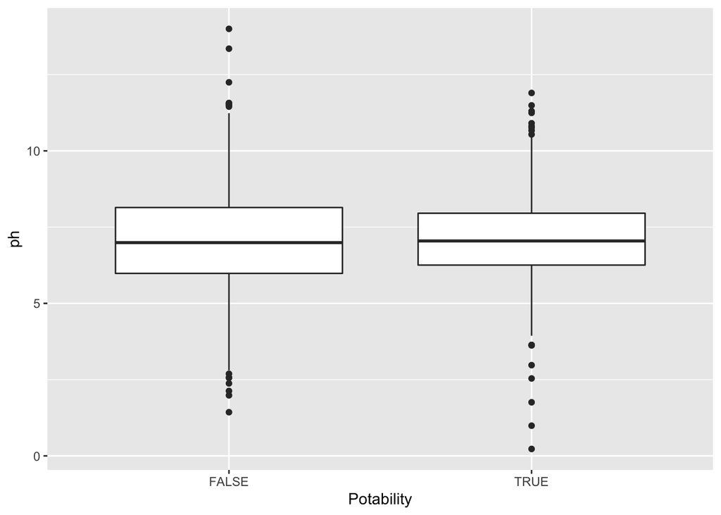

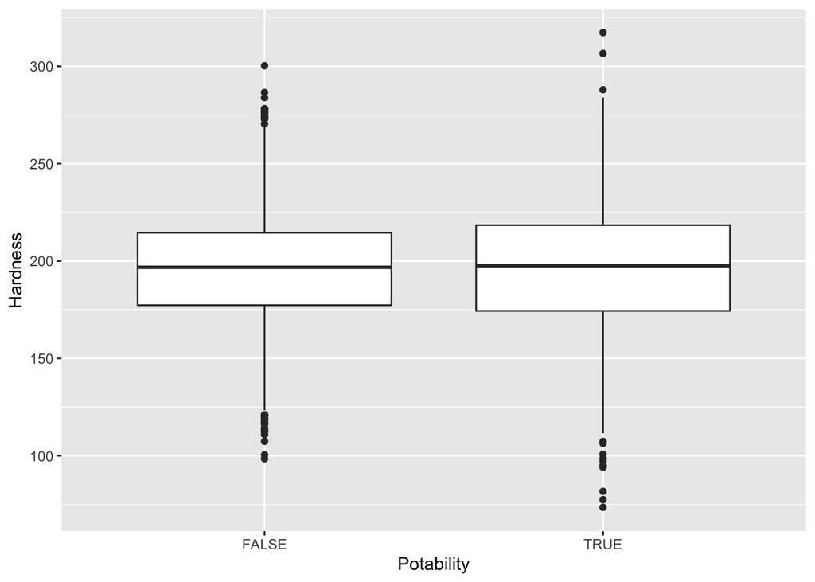

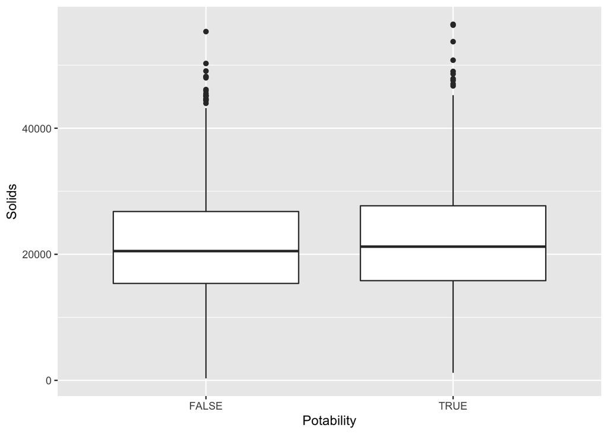

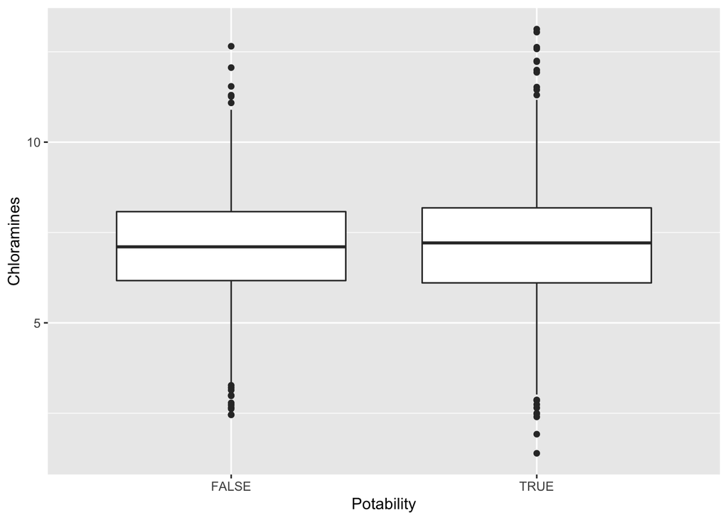

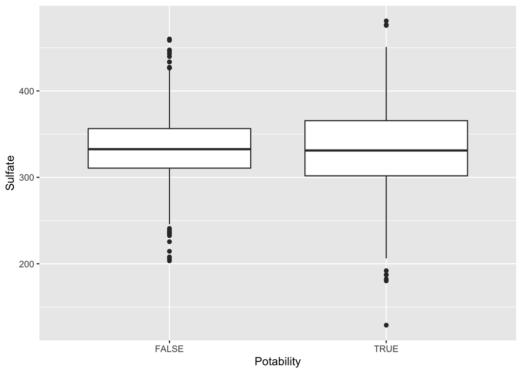

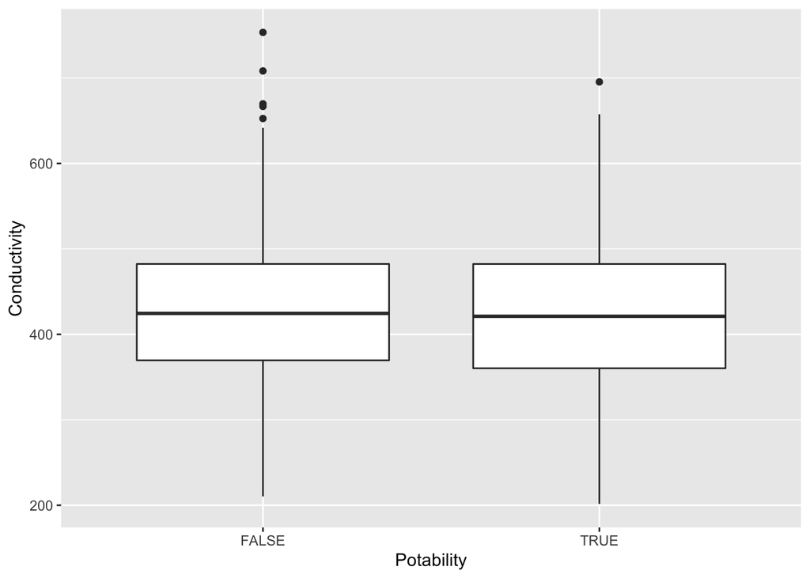

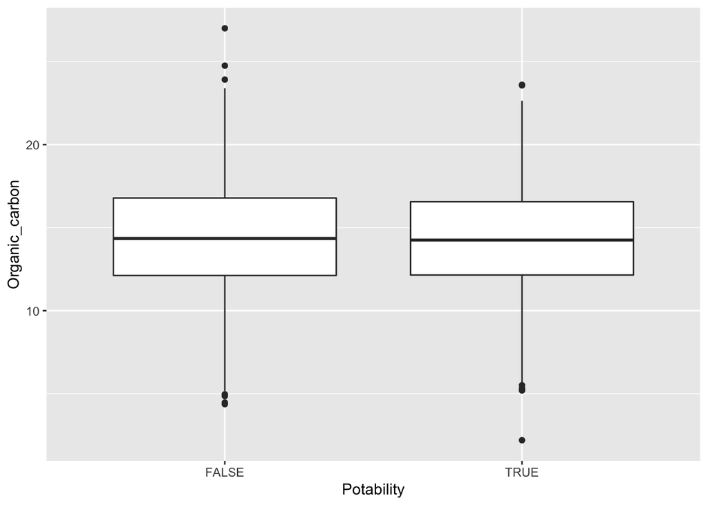

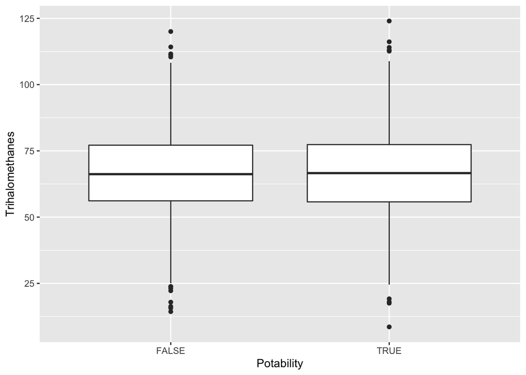

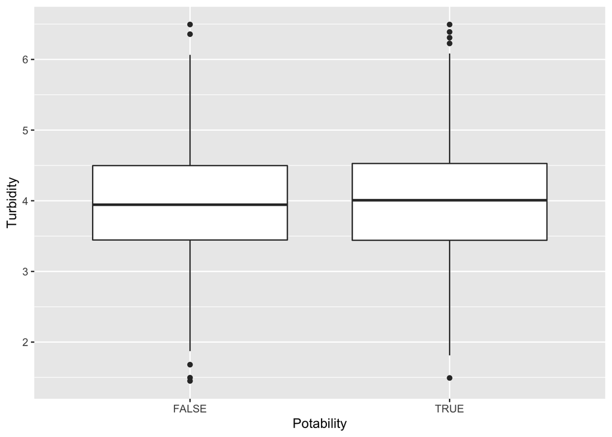

## Correlation Matrix

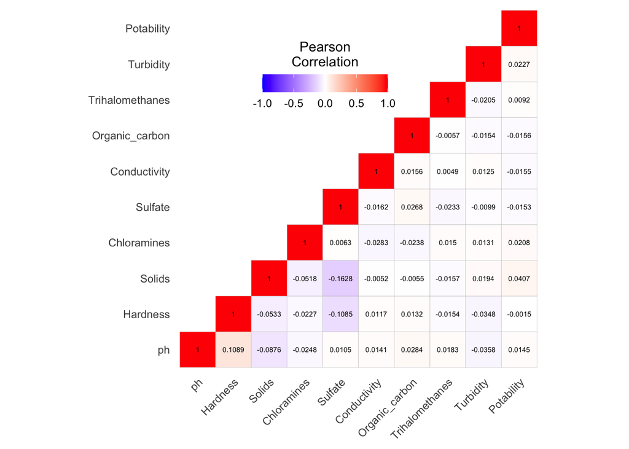

## Distribution plots for each feature

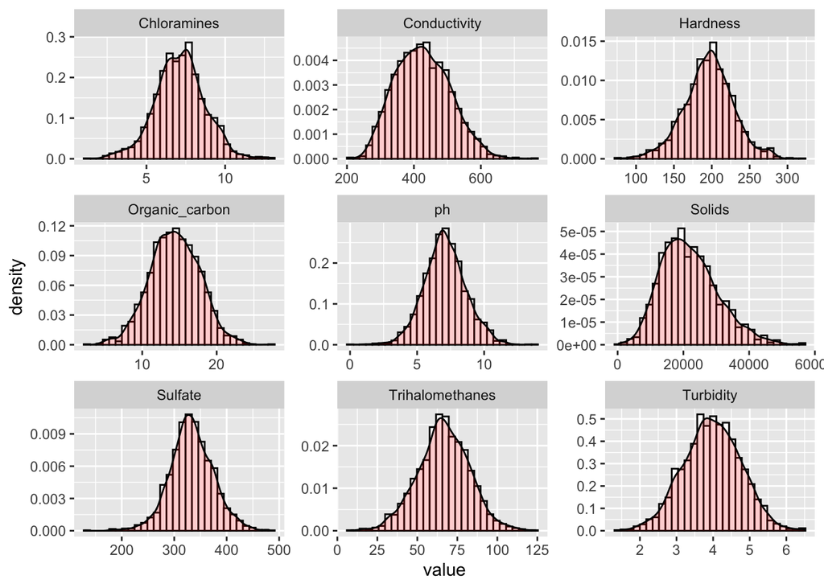

## Remove Outliers

Using the interquartile range I removed 222 rows total from the data set to adjust the variable skew.

```r
outliers <- function(x) {

  q1 <- quantile(x, probs=.25)
  q3 <- quantile(x, probs=.75)
  iqr = q3-q1
  upper_limit = q3 + (iqr*1.5)
  lower_limit = q1 - (iqr*1.5)
  x > upper_limit | x < lower_limit
}

remove_outliers <- function(df, cols = names(df)) {
  for (col in cols) {
    df <- df[!outliers(df[[col]]),]
  }
  df
}

# counting removed outliers

nrow(wq_df) - nrow(remove_outliers(wq_df, col_names)) # 222 rows will be removed
```

```
## [1] 222
```

```r
# create new dataframe without outliers

wq_df_v2 <- remove_outliers(wq_df, col_names)
```

## Skew Adjustments

After the skew adjustments, we can see a large improvement within Hardness and Solids. However, features such as Chloramines and Turbidity saw worse skew after the adjustment. Perhaps it would be better to ignore features that already have skew under .1. Then apply a log transformation to Conductivity and Solids, since they are both positively skewed with a skewness over .2.

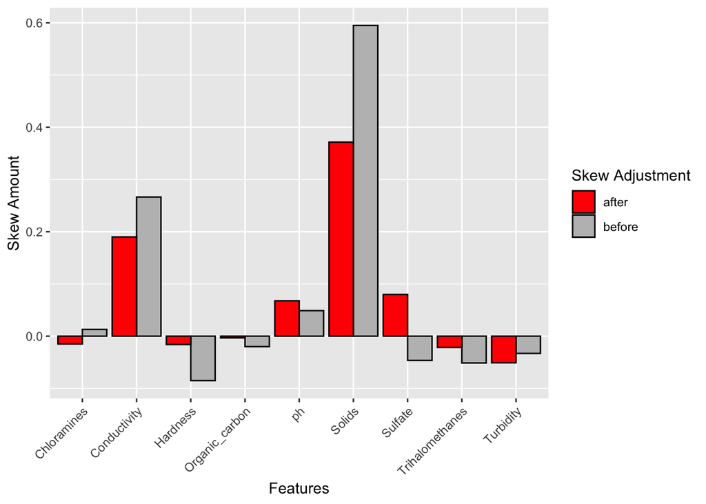

## Distribution Plots after Skew Adjustments

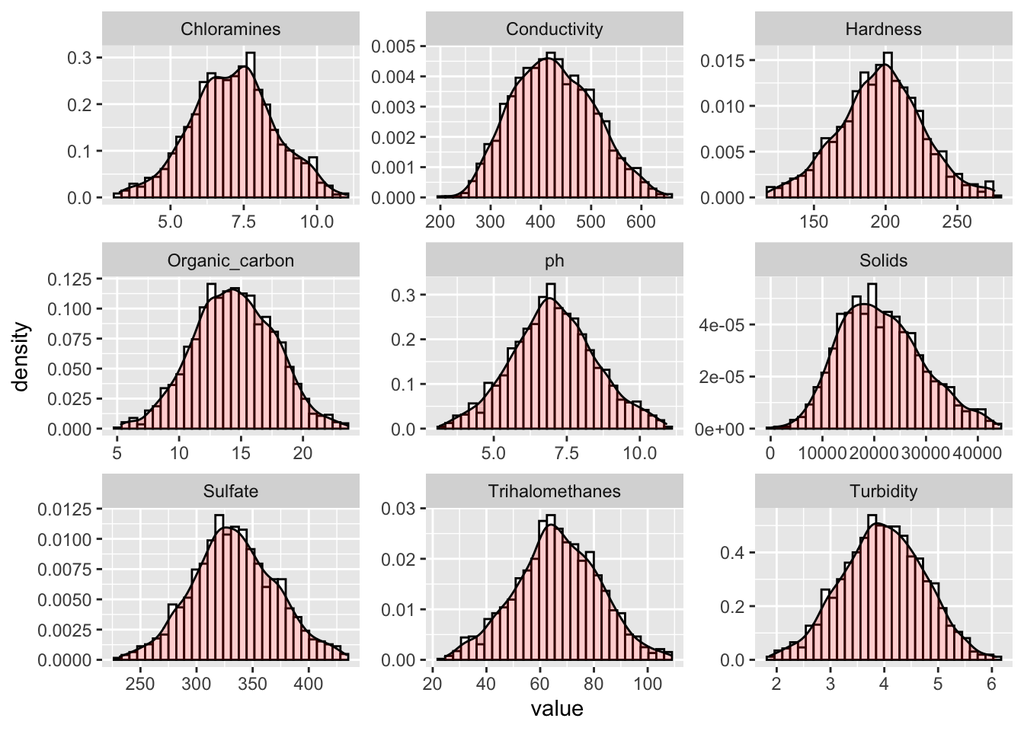

## Partitioning and Normalizing the Data

```r
# convert potability label to factor for predictions

wq_df_v2 <- wq_df_v2 %>% mutate(Potability = as.factor(Potability))

# create training and test sets

set.seed(355)
train_index <- createDataPartition(wq_df_v2$Potability, p = .7, list = FALSE)
train_set <- wq_df_v2[train_index,]
test_set <- wq_df_v2[-train_index,]

# normalize train and test set

data_norm <- function(x) {
  ((x - min(x))/(max(x)-min(x)))
}

train_set_norm <- as.data.frame(lapply(train_set[1:9], data_norm))
test_set_norm <- as.data.frame(lapply(test_set[1:9], data_norm))

# bind normalized training set with potability label

train_set_norm <- cbind(Potability = train_set$Potability ,train_set_norm)
```

## Random Forest Prediction and Confusion Matrix

The model ran 25 bootstrap samples as the resampling method. In addition, the model chose Mtry=9, meaning the model used 9 nodes while splitting a tree. Accuracy is 67% with sensitivity at 38% and specificity at 87%.

```
## Random Forest
##
## 1253 samples
##    9 predictor
##    2 classes: 'FALSE', 'TRUE'
##
## No pre-processing
## Resampling: Bootstrapped (25 reps)
## Summary of sample sizes: 1253, 1253, 1253, 1253, 1253, 1253, ...
## Resampling results across tuning parameters:
##
##   mtry  Accuracy   Kappa
##   2     0.6506146  0.2005359
##   5     0.6530266  0.2190350
##   9     0.6540321  0.2265378
##
## Accuracy was used to select the optimal model using the largest value.
## The final value used for the model was mtry = 9.
```

```
## Confusion Matrix and Statistics
##
##           Reference
## Prediction FALSE TRUE
##      FALSE   283  131
##      TRUE     43   79
##
##                Accuracy : 0.6754
##                  95% CI : (0.6339, 0.7149)
##     No Information Rate : 0.6082
##     P-Value [Acc > NIR] : 0.0007494
##
##                   Kappa : 0.264
##
##  Mcnemar's Test P-Value : 4.24e-11
##
##             Sensitivity : 0.3762
##             Specificity : 0.8681
##          Pos Pred Value : 0.6475
##          Neg Pred Value : 0.6836
##               Precision : 0.6475
##                  Recall : 0.3762
##                      F1 : 0.4759
##              Prevalence : 0.3918
##          Detection Rate : 0.1474
##    Detection Prevalence : 0.2276
##       Balanced Accuracy : 0.6221
##
##        'Positive' Class : TRUE
##
```

## KNN Prediction and Confusion Matrix

This model also ran 25 bootstrap samples as the resampling method. In addition, the model chose k=9, meaning each point is predicted based on the 9 closest points in terms of euclidean distance. Accuracy is slightly worse at 64% with sensitivity at 35% and specificity at 83%.

```
## k-Nearest Neighbors
##
## 1253 samples
##    9 predictor
##    2 classes: 'FALSE', 'TRUE'
##
## No pre-processing
## Resampling: Bootstrapped (25 reps)
## Summary of sample sizes: 1253, 1253, 1253, 1253, 1253, 1253, ...
## Resampling results across tuning parameters:
##
##   k  Accuracy   Kappa
##   5  0.5956036  0.1286533
##   7  0.6038288  0.1370069
##   9  0.6062660  0.1381046
##
## Accuracy was used to select the optimal model using the largest value.
## The final value used for the model was k = 9.
```

```
## Confusion Matrix and Statistics
##
##           Reference
## Prediction FALSE TRUE
##      FALSE   269  135
##      TRUE     57   75
##
##                Accuracy : 0.6418
##                  95% CI : (0.5996, 0.6824)
##     No Information Rate : 0.6082
##     P-Value [Acc > NIR] : 0.06017
##
##                   Kappa : 0.1952
##
##  Mcnemar's Test P-Value : 2.745e-08
##
##             Sensitivity : 0.3571
##             Specificity : 0.8252
##          Pos Pred Value : 0.5682
##          Neg Pred Value : 0.6658
##               Precision : 0.5682
##                  Recall : 0.3571
##                      F1 : 0.4386
##              Prevalence : 0.3918
##          Detection Rate : 0.1399
##    Detection Prevalence : 0.2463
##       Balanced Accuracy : 0.5911
##
##        'Positive' Class : TRUE
##
```

## Variable Importance for each model

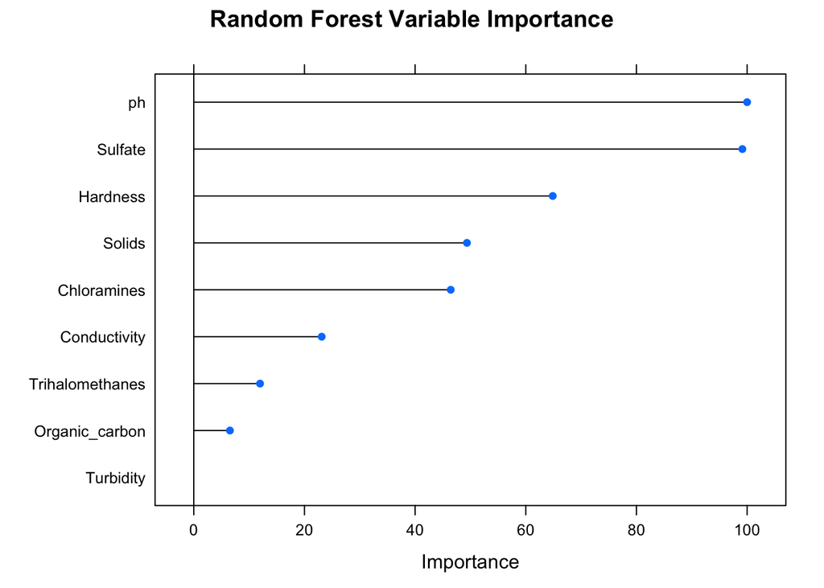

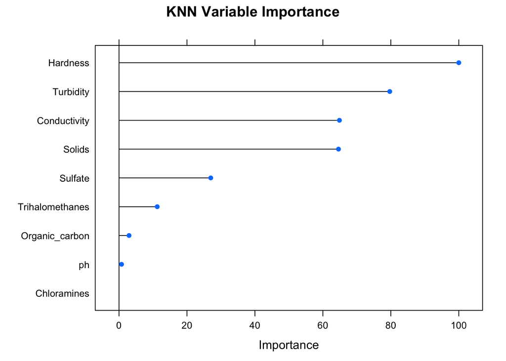

## Conclusion

As seen with the correlation matrix reflecting low correlation values amongst variables, this is a tough classification problem. However there are a number of ways to improve this model. Moving forward, considering we are predicting whether or not water is clean to drink, I’d certainly want to optimize for specificity. That would be my targeted metric as I continue constructing a better model with this data set. That being said, there are a couple improvements I would focus on next to increase both accuracy and specificity. The first regarding skew transformations, which I mentioned earlier. Another idea would be to drop variables such as Organic Carbon and Trihalomethane to reduce noise, because both those features were unimportant under the KNN and Random Forest models.